# Batch processing TerraClim data

Dr. Greg Torda

2024-11-13

In the [previous tutorial](https://dontorda.github.io/climate_web.html) we looked at how we can getlong-term TerraClimate data for a single point, and fit a GAM on the time-series data.

In this tutorial we will explore how we can download TerraClimate data for larger areas in batches and create difference rasters for pairs of years or pairs of multi-year climatologies. Our specific aim will be to create difference rasters for the entire world, contrasting 1958 to 2023, and the first ten years of the TerraClimate dataset (1958-1967 period) to the last 10 years (2014-2023 period). We will produce neat world maps which will show which areas have been warming fastest, or loosing or gaining precipitation.

# Preparations

Load the necessary libraries.

```r
library(colorspace)
library(lubridate)
library(tidyverse)
library(knitr)     #for kable
library(sf)
library(climateR)
library(colorjam)
library(progress)  #for progress bar, if you like
library(terra)
library(climateR)

theme_set(theme_bw())
```

# Batch download terra climate data

We will start with a script that downloads multiple TerraClimate variables for user-defined periods and areas.

The variables we will download are:

```r
variables = tibble(var = c("aet", "def", "pet", "ppt", "tmax", "tmin"),
                   variable = c('Actual evapotranspiration (mm)',
                                'Climatic water deficit (mm)',
                                'Potential evapotranspiration (mm)',
                                'Monthly total precipitation (mm)',
                                'Monthly average maximum temperature (°C)',
                                'Monthly average minimum temperature (°C)'))

variables %>% kable()
```

| var | variable |
| --- | --- |
| aet | Actual evapotranspiration (mm) |
| def | Climatic water deficit (mm) |
| pet | Potential evapotranspiration (mm) |
| ppt | Monthly total precipitation (mm) |
| tmax | Monthly average maximum temperature (°C) |
| tmin | Monthly average minimum temperature (°C) |

First we will define an area of interest (AOI) for the entire world, then create a loop that downloads and saves the rasters of the target variables for each year of interest.  
**Note that saving the downloaded SpatRast objects as .RData file often fails, which is why we will save them as .tif files**.  
**Also note that this process takes VERY long, so be patient and/or run it overnight**.

```r
# Define AOI for the entire world
aoi <- st_as_sf(st_as_sfc(st_bbox(c(xmin = -180, ymin = -90, xmax = 180, ymax = 90), crs = st_crs(4326))))

# Define the range of years to download
start_year <- 1958 #change to 2014 for a second batch
end_year <- 1967 #change to 2023 for a second batch

# Loop through each year
for (year in start_year:end_year) {
  # Create the directory for the year
  dir_name <- paste0("./data/globClim_", year)
  dir.create(dir_name, showWarnings = FALSE)

  # List of variables to download
  varnames <- variables %>% pull(var)

  # Loop through each variable
  for (varname in varnames) {
    success <- FALSE
    attempts <- 1
    max_attempts <- 15  # Set a limit to prevent infinite loops
    print(paste0("Downloading variable:", varname, " for year:", year, ", attempt ", attempts))

    while (!success && attempts < max_attempts) {
      attempts <- attempts + 1
      tryCatch({
        # Download the TerraClim data for the specific variable
        raster_data <- getTerraClim(
          AOI = aoi,
          varname = varname,
          startDate = paste0(year, "-01-01"),
          endDate = paste0(year, "-12-31")
        )

        # Make sure that we only have the 12 layers for the 12 months (getTerraClim tends to download the next years January data, too)
        r12 <- terra::subset(raster_data[[1]], 1:12)
        # time(r12)

        # Save the raster to the directory
        writeRaster(
          r12,
          filename = paste0(dir_name, "/globClim_", year, "_", varname, ".tif"),
          overwrite = TRUE
        )

        # Mark success
        success <- TRUE
      }, error = function(e) {
        # Print the error message and retry
        message(paste("Error downloading variable:", varname, "for year:", year, "\n", e$message))
        message("Retrying... (Attempt ", attempts, " of ", max_attempts, ")")
      })
    }

    # If after max attempts, it's still unsuccessful
    if (!success) {
      message(paste("Failed to download variable:", varname, "for year:", year, "after", max_attempts, "attempts."))
    }
  }
}
```

Now then, sometimes your rasters will not download fully, they will be ‘corrupted’. You can run a ‘quick’ (haha) check to see which ones need more attention, if any. **Note: this will actually take a long time, too, sorry**.

```r
# Define the folder containing the .tif files
folder_path <- "./data"

# List all .tif files in the folder
tif_files <- list.files(folder_path, pattern = "\\.tif$", full.names = TRUE, recursive = T)

# Create a log to store problematic files
problem_log <- data.frame(File = character(), Issue = character(), stringsAsFactors = FALSE)

# Initialize progress bar
pb <- progress_bar$new(
  format = "Processing [:bar] :percent (:current/:total) Elapsed: :elapsed",
  total = length(tif_files),
  clear = FALSE,
  width = 60
)

# Check each file
for (file in tif_files) {
  pb$tick()  # Update progress bar

  # Load the raster stack
  raster_stack <- try(terra::rast(file), silent = TRUE)

  if (inherits(raster_stack, "try-error")) {
    # Log if the file could not be read
    problem_log <- rbind(problem_log, data.frame(File = file, Issue = "Cannot load file"))
    next
  }

  # Check for -99 in all layers using terra::values()
  values_matrix <- try(values(raster_stack), silent = TRUE)

  if (inherits(values_matrix, "try-error")) {
    # Log if the values could not be extracted
    problem_log <- rbind(problem_log, data.frame(File = file, Issue = "Cannot read values"))
    next
  }

  if (any(values_matrix == -99, na.rm = TRUE)) {
    # Log the file name if any -99 is found
    problem_log <- rbind(problem_log, data.frame(File = file, Issue = "-99 values found"))
  }
}
```

If you don’t have any errors in your downloads, hurray. If you do, you may want to download them again. Here is a loop to do just that.

```r
errFiles <- unique(problem_log$File)

# Define AOI
aoi <- st_as_sf(st_as_sfc(st_bbox(c(xmin = -180, ymin = -90, xmax = 180, ymax = 90), crs = st_crs(4326))))

# Define maximum attempts for retrying downloads
max_attempts <- 15

# Loop through each erroneous file
for (filename in errFiles) {
  # Extract year and variable using regex
  match <- regexec("globClim_(\\d{4})_(\\w+)\\.tif$", filename)
  matches <- regmatches(filename, match)[[1]]
  year <- matches[2]
  varname <- matches[3]

  # Define directory for the year
  dir_name <- paste0("./data/globClim_", year)

  # Retry logic for downloading
  success <- FALSE
  attempts <- 0

  while (!success && attempts < max_attempts) {
    attempts <- attempts + 1
    tryCatch({
      # Download the TerraClim data
      raster_data <- getTerraClim(
        AOI = aoi,
        varname = varname,
        startDate = paste0(year, "-01-01"),
        endDate = paste0(year, "-12-31")
      )

      # Make sure that we only have the 12 layers for the 12 months (getTerraClim tends to download the next years January data, too)
      r12 <- terra::subset(raster_data[[1]], 1:12)
      # time(r12)

      # Save the raster to the directory
      writeRaster(
        r12,
        filename = paste0(dir_name, "/globClim_", year, "_", varname, ".tif"),
        overwrite = TRUE
      )

      # Mark success
      success <- TRUE
      message(paste("Successfully downloaded:", varname, "for year:", year))
    }, error = function(e) {
      # Print the error message and retry
      message(paste("Error downloading variable:", varname, "for year:", year, "\n", e$message))
      message("Retrying... (Attempt ", attempts, " of ", max_attempts, ")")
    })
  }

  # If after max attempts, it's still unsuccessful
  if (!success) {
    message(paste("Failed to download variable:", varname, "for year:", year, "after", max_attempts, "attempts."))
  }
}
```

Now we should have all the data sets we need for this tutorial: TerraClimate data for the variables listed above, for 1958-1967 and 2014-2023.

# Compare single years

The .tif files we created above are organized by year and variable, with each file containing 12 layers corresponding to the months. We will read all six .tif files for each year as a list of SpatRaster objects and calculate difference rasters by stepping through the list and comparing pairs of months. These difference rasters will then be saved as PNG files, organized in a neat folder structure.  
For precipitation, the color scale will use a logarithmic (log10) transformation because its values exhibit a wide range relative to the mean. On a linear scale, small changes would be hard to distinguish due to this large variability.

```r
# List all .tif files
tif_files <- list.files('./data/', pattern = "\\.tif$", full.names = TRUE, recursive = TRUE)

# Load files containing "1958" into a list
r1958 <- lapply(tif_files[grep("1958", tif_files)], rast)

# Load files containing "2023" into a list
r2023 <- lapply(tif_files[grep("2023", tif_files)], rast)

# Perform cell-by-cell subtraction
gc_diff <- Map(function(rast1, rast2) {
  # Ensure both SpatRast have the same number of layers
  if (nlyr(rast1) != nlyr(rast2)) {
    stop("Mismatch in the number of layers between SpatRast objects")
  }

  # Subtract layer by layer
  rast2 - rast1
}, r1958, r2023)

dir.create('./difference rasters 2023 vs 1958/', showWarnings = FALSE)

# Write each difference raster to a file
for (i in seq_along(gc_diff)) {

  var_name <-  unique(sub("_.*", "", names(gc_diff[[i]]))) # Extract the name of the variable

  dir.create(paste0('./difference rasters 2023 vs 1958/', var_name), showWarnings = FALSE)
  terra::writeRaster(gc_diff[[i]],
                     filename = paste0('./difference rasters 2023 vs 1958/', var_name, '/', var_name, "_2023_1958_diff.tif"),
                     overwrite = TRUE)  # No 'format' argument

  variable <- variables[i, 2]

  # Get the global min and max values across the 12 layers for the current variable
  min_value <- min(values(gc_diff[[i]]), na.rm = TRUE)
  max_value <- max(values(gc_diff[[i]]), na.rm = TRUE)

  end_values <- max(abs(min_value), max_value)
  zlim <- c(-end_values, end_values)  # Fixed zlim for all 12 maps of this variable
  if (var_name %in% c('ppt')) {
    zlim <- sign(zlim) * log10(abs(round(zlim, -3)) + 1)
  }

  # Loop over the 12 months (layers of the raster)
  for (j in 1:12) {
    # Progress message
    message(paste("Processing:", var_name, "- Month:", month.name[j]))

    # Convert the raster layer to a data frame for ggplot2
    raster_df <- as.data.frame(gc_diff[[i]][[j]], xy = TRUE)
    colnames(raster_df) <- c("x", "y", "value")

    # Generate the PNG file path
    png_filename <- paste0('./difference rasters 2023 vs 1958/', var_name, '/', var_name, '_2023_1958_diff_', sprintf("%02d", j), ".png")

    if (var_name %in% c('ppt')) {
      raster_df$value <- sign(raster_df$value) * log10(abs(raster_df$value) + 1)}

    # Create the plot with ggplot2
    breaks <- seq(zlim[1], zlim[2], length.out = 5)

    p <- ggplot(raster_df, aes(x = x, y = y, fill = value)) +
      geom_tile() +
      scale_fill_gradientn(
        colors = rev(divergingx_hcl(100, palette = "RdBu")),
        limits = zlim,
        breaks = breaks,
        labels = if (var_name %in% c('ppt')) {
          function(x) round(sign(x) * (10^abs(x) - 1))  # Round to integers
        } else {
          scales::label_number(accuracy = 1)  # Force integer rounding
        },
        # trans = "exp",
        guide = guide_colorbar(
          barheight = grid::unit(3, "in"),  # Adjust height (e.g., 3 inches)
          barwidth = grid::unit(0.2, "in")  # Adjust width (optional)
        )
      ) +
      coord_fixed() +
      labs(
        title = ifelse(var_name %in% c('ppt'),
                       paste0(variable, " - difference (log10 color scale) between ", month.name[j], ' 1958 and 2023'),
                       paste0(variable, " - difference between ", month.name[j], ' 1958 and 2023')),
        x = "",
        y = "",
        fill = ''
      ) +
      theme_minimal() +
      theme(plot.title = element_text(hjust = 0.5, size = 14))

    # Save the plot
    ggsave(png_filename, plot = p, width = 10, height = 8, dpi = 150)
  }
}
```

And here is what some of our plots look like: the differences in precipitation, maximum and minimum temperatures in July in 2023 vs 1958.

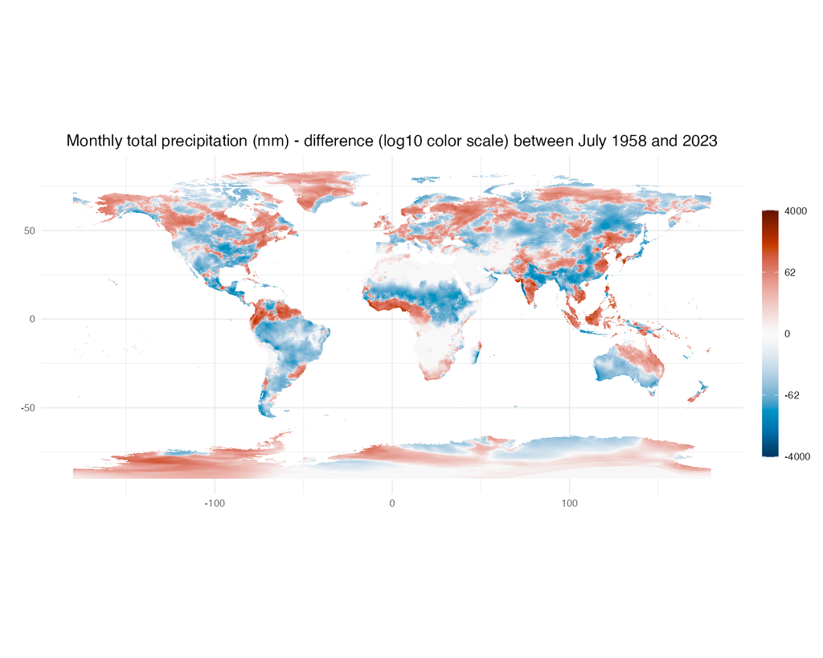

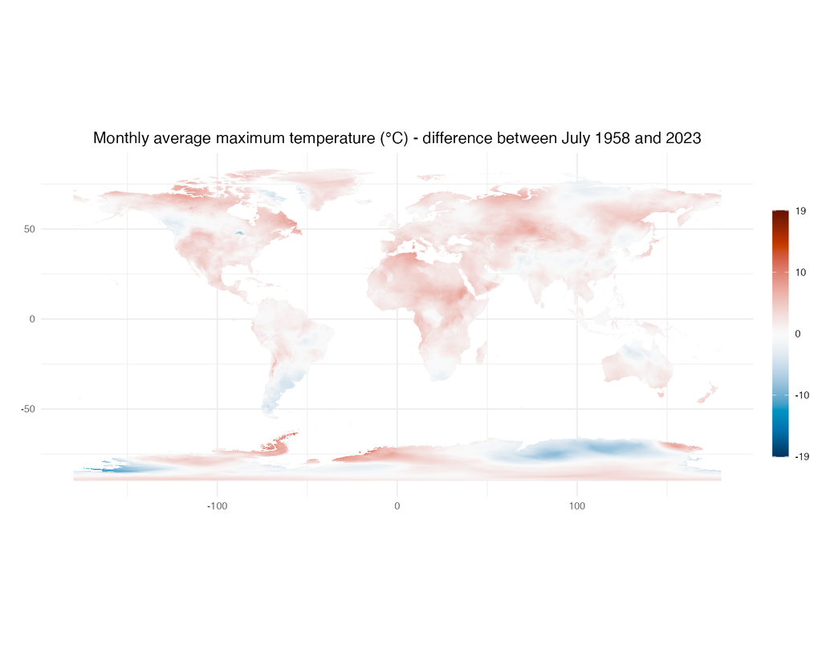

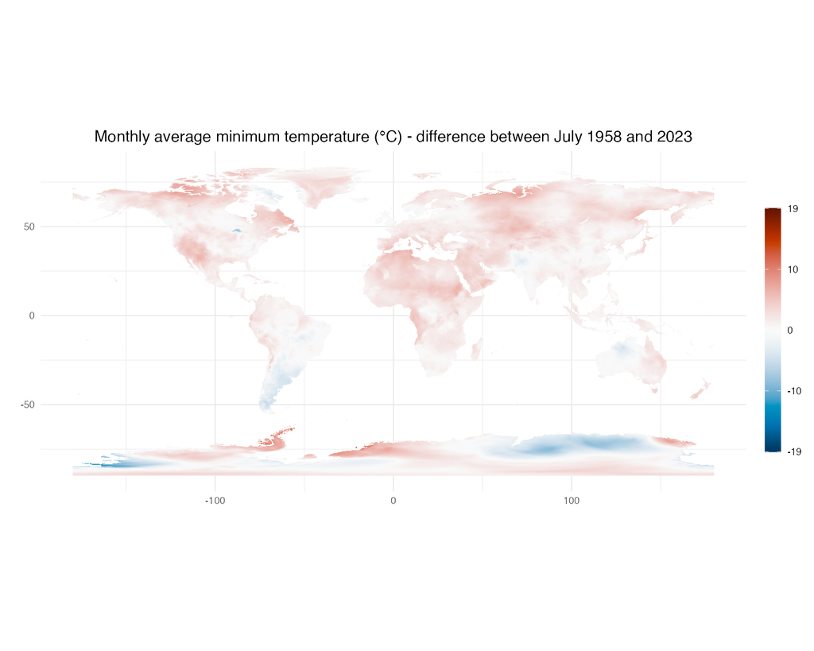

```r
# Paths to the saved images
image_paths <- c(
  "./difference rasters 2023 vs 1958/ppt/ppt_2023_1958_diff_07.png",
  "./difference rasters 2023 vs 1958/tmax/tmax_2023_1958_diff_07.png",
  "./difference rasters 2023 vs 1958/tmin/tmin_2023_1958_diff_07.png"
)

# Include the images
include_graphics(image_paths)
```

This is beautiful and informative, but one might argue that perhaps 1958 and 2023 were odd years when one or more of these variables exhibited unusual patterns, which may skew our interpretation of the results. This is when climatology can come in. We can calculate a mean raster for every variable and every month of certain time periods, e.g. for the first ten years (1958-1967) and the last ten years (2014-2023), and calculate the difference rasters from those instead. This approach will eliminate annual anomalies, and will therefore give us a more robust estimate of spatial and temporal changes in the plotted variables.

# Compare climatology

So the first step is to load the rasters from the first ten years, and calculate the average of each variable for each month. Then we do the same for the last ten years.

```r
periods <- list(c(1958, 1967), c(2014, 2023))
dir.create("./average", showWarnings = FALSE)

for (V in varies$var) {
  for (P in periods) {

  start_year <- P[1]
  end_year <- P[2]

  # List all files with the pattern
  all_files <- list.files("./data", pattern = paste0("globClim_.*_", V, "\\.tif$"), full.names = TRUE, recursive = TRUE)

  # Extract years from filenames
  filtered_files <- all_files[sapply(all_files, function(x) {
    # Extract year from the filename
    year <- as.numeric(gsub(".*globClim_(\\d{4}).*", "\\1", x))
    # Check if the year is within the range
    !is.na(year) && year >= start_year && year <= end_year
  })]

  # Read only the filtered files
  r <- lapply(filtered_files, rast)

  # plot(ppt1_t[[10]])

  # Initialize an empty list to store the averaged layers
  monthly_averages <- vector("list", 12)

  # Loop through each month (layer 1 to 12)
  for (month in 1:12) {
    # Extract the corresponding layer from each year's raster
    monthly_layers <- lapply(r_trim, `[`, month)

    # Combine and calculate the average
    monthly_averages[[month]] <- mosaic(monthly_layers, fun = mean, na.rm = TRUE)
  }

  # Combine the averaged monthly layers into a single SpatRaster
  average_raster <- do.call(c, monthly_averages)

  # Set the layer names to the month names
  names(average_raster) <- month.name

  # Save the final averaged raster to a file (optional)
  writeRaster(average_raster, filename = paste0("./average/average_monthly_raster_", V, "_", start_year, "_", end_year, ".tif"), overwrite = TRUE)
  }
}
```

Then we want to take the pairs of climatology rasters, per variable and per month, for the period 2014-2023 and 1958-1967 and calculate their difference, just like we did before for single years.

```r
# List all .tif files
tif_files <- list.files('./average', pattern = "\\.tif$", full.names = TRUE, recursive = TRUE)

# Load files containing "1958" into a list
r1958_clim <- lapply(tif_files[grep("1958", tif_files)], rast)

# Load files containing "2023" into a list
r2023_clim <- lapply(tif_files[grep("2023", tif_files)], rast)

# Perform cell-by-cell subtraction
gc_diff_clim <- Map(function(rast1, rast2) {
  # Ensure both SpatRast have the same number of layers
  if (nlyr(rast1) != nlyr(rast2)) {
    stop("Mismatch in the number of layers between SpatRast objects")
  }

  # Subtract layer by layer
  rast2 - rast1
}, r1958_clim, r2023_clim)

dir.create('./difference rasters 2014-2023 vs 1958-1967/', showWarnings = FALSE)

# Write each difference raster to a file
for (i in seq_along(gc_diff_clim)) {

  var_name <-  unique(sub(".*_raster_(.*?)_.*", "\\1", varnames(gc_diff_clim[[i]]))) # Extract the name of the variable

  dir.create(paste0('./difference rasters 2014-2023 vs 1958-1967/', var_name), showWarnings = FALSE)
  terra::writeRaster(gc_diff_clim[[i]],
                     filename = paste0('./difference rasters 2014-2023 vs 1958-1967/', var_name, '/', var_name, "_2023_1958_diff.tif"),
                     overwrite = TRUE)  # No 'format' argument

  variable <- variables %>%
  filter(var == var_name) %>%
  pull(variable)

  # Get the global min and max values across the 12 layers for the current variable
  min_value <- min(values(gc_diff_clim[[i]]), na.rm = TRUE)
  max_value <- max(values(gc_diff_clim[[i]]), na.rm = TRUE)

  end_values <- max(abs(min_value), max_value)
  zlim <- c(-end_values, end_values)  # Fixed zlim for all 12 maps of this variable
  if (var_name %in% c('ppt')) {
    zlim <- sign(zlim) * log10(abs(round(zlim, -3)) + 1)
  }

  # Loop over the 12 months (layers of the raster)
  for (j in 1:12) {
    # Progress message
    message(paste("Processing:", var_name, "- Month:", month.name[j]))

    # Convert the raster layer to a data frame for ggplot2
    raster_df <- as.data.frame(gc_diff_clim[[i]][[j]], xy = TRUE)
    colnames(raster_df) <- c("x", "y", "value")

    # Generate the PNG file path
    png_filename <- paste0('./difference rasters 2014-2023 vs 1958-1967/', var_name, '/', var_name, '_2014-2023_1958-1967_diff_', sprintf("%02d", j), ".png")

    if (var_name %in% c('ppt')) {
      raster_df$value <- sign(raster_df$value) * log10(abs(raster_df$value) + 1)}

    # Create the plot with ggplot2
    breaks <- seq(zlim[1], zlim[2], length.out = 5)

    p <- ggplot(raster_df, aes(x = x, y = y, fill = value)) +
      geom_tile() +
      scale_fill_gradientn(
        colors = rev(divergingx_hcl(100, palette = "RdBu")),
        limits = zlim,
        breaks = breaks,
        labels = if (var_name %in% c('ppt')) {
          function(x) round(sign(x) * (10^abs(x) - 1))  # Round to integers
        } else {
          scales::label_number(accuracy = 1)  # Force integer rounding
        },
        # trans = "exp",
        guide = guide_colorbar(
          barheight = grid::unit(3, "in"),  # Adjust height (e.g., 3 inches)
          barwidth = grid::unit(0.2, "in")  # Adjust width (optional)
        )
      ) +
      coord_fixed() +
      labs(
        title = paste0(variable, " in ", month.name[j]),
        subtitle = ifelse(var_name %in% c('ppt'),
                       "difference (log10 color scale) between the climatologies of 2014-2023 vs 1958-1967",
                       "difference between the climatologies of 2014-2023 vs 1958-1967"),
        x = "",
        y = "",
        fill = ''
      ) +
      theme_minimal() +
      theme(plot.title = element_text(hjust = 0.5, size = 14),
            plot.subtitle = element_text(hjust = 0.5, size = 12))

    # Save the plot
    ggsave(png_filename, plot = p, width = 10, height = 8, dpi = 150)
  }
}
```

And here is what some of our plots look like: the differences in precipitation, maximum and minimum temperatures in July of the periods 2014-2023 vs 1958-1967.

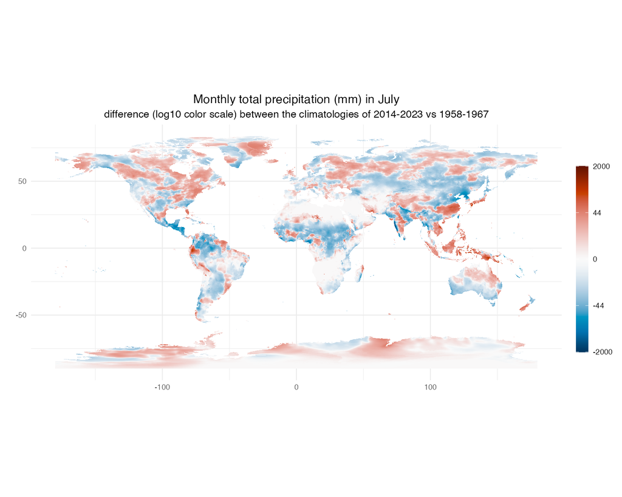

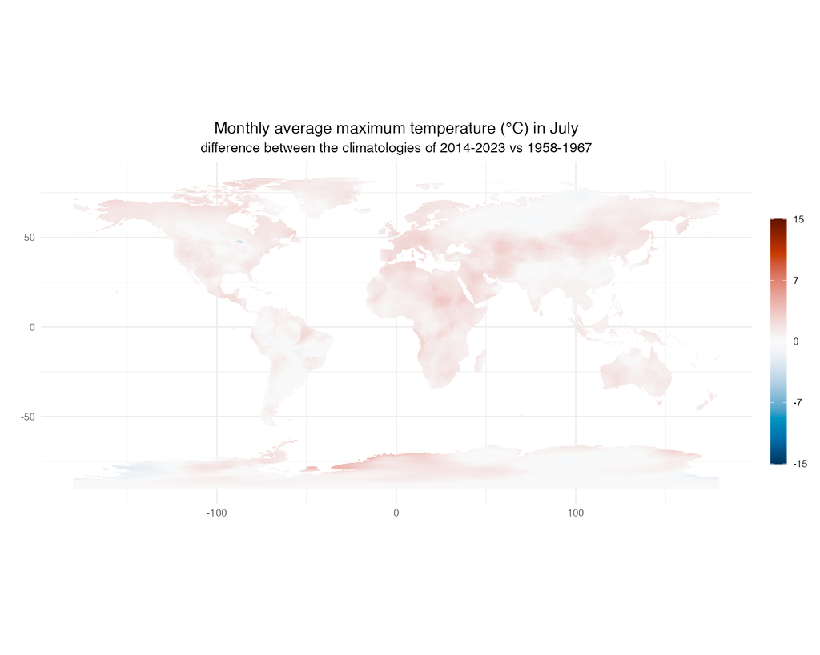

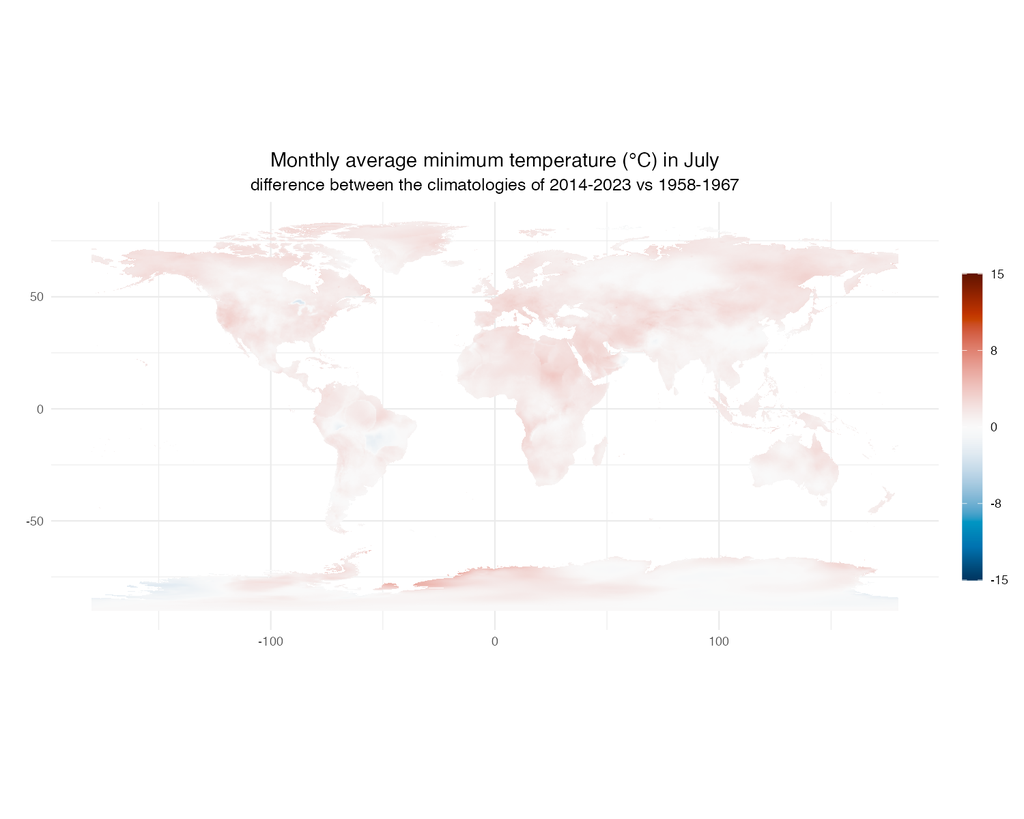

```r
# Paths to the saved images
image_paths <- c(
  "./difference rasters 2014-2023 vs 1958-1967/ppt/ppt_2014-2023_1958-1967_diff_07.png",
  "./difference rasters 2014-2023 vs 1958-1967/tmax/tmax_2014-2023_1958-1967_diff_07.png",
  "./difference rasters 2014-2023 vs 1958-1967/tmin/tmin_2014-2023_1958-1967_diff_07.png"
)

# Include the images
include_graphics(image_paths)
```

Voila! We have the difference rasters of the two climatologies, which should be more robust and informative than the difference of single years. And we can marvel at the spatial patterns of increase and decrease in climate variables.